# Comparing Cenote-Taker 3 and Genomad Discovery on short read metagenome assemblies

Cenote-Taker 3 and Genomad both can discover viruses in metagenomic data. Short read assemblies are still pervasive, so a benchmark on these data is informative.

```r
# load libraries
library(data.table)
library(stringr)
library(dplyr)
library(tidyr)
library(ggplot2)
library(forcats)
library(rprojroot)
library(ggupset)
```

## Functions

```r
#' Tag overlapping windows (≥25 % overlap) with a unique ID
#' @param df         data.frame / data.table containing window rows
#' @param contig_col column name holding contig values (default "contig")
#' @param start_col  column name holding window start (default "start")
#' @param stop_col   column name holding window stop  (default "stop")
#' @return           original data with new column `ovl_id`
assign_overlap_id <- function(df,
                              contig_col = "contig",
                              start_col  = "start",
                              stop_col   = "stop") {
  stopifnot(contig_col %in% names(df),
            start_col  %in% names(df),
            stop_col   %in% names(df))

  # convert to data.table for efficient in-place ops
  dt <- as.data.table(df)

  # standardise working names
  setnames(dt,
           c(contig_col, start_col, stop_col),
           c("contig__", "start__", "stop__"))

  setorder(dt, contig__, start__, stop__)

  # helper to tag one contig cluster vectorised over rows
  tag_one <- function(start_vec, stop_vec) {
    n <- length(start_vec)
    grp <- integer(n)
    cur_tag <- 1L
    cur_s <- start_vec[1]
    cur_e <- stop_vec[1]
    cur_len <- cur_e - cur_s
    grp[1] <- cur_tag
    if (n > 1L) {
      for (i in 2:n) {
        len_i <- stop_vec[i] - start_vec[i]
        ovl   <- min(cur_e, stop_vec[i]) - max(cur_s, start_vec[i])
        if (ovl > 0 &&
            ovl >= 0.25 * pmin(len_i, cur_len)) {
          grp[i] <- cur_tag
          if (stop_vec[i] > cur_e) {
            cur_e  <- stop_vec[i]
            cur_len <- cur_e - cur_s
          }
        } else {
          cur_tag <- cur_tag + 1L
          grp[i]  <- cur_tag
          cur_s <- start_vec[i]
          cur_e <- stop_vec[i]
          cur_len <- cur_e - cur_s
        }
      }
    }
    grp
  }

  dt[, ovl_grp := tag_one(start__, stop__), by = contig__]
  dt[, ovl_id  := paste0(contig__, "_", ovl_grp)]

  # restore original column names
  setnames(dt,
           c("contig__", "start__", "stop__"),
           c(contig_col, start_col, stop_col))

  invisible(dt[])
}
```

## VLP Accessions

ERR8081307, ERR8081362, ERR8081370

load tables

```r
ERR8081307_ct_sum_dt <- fread(
  sprintf(
    "%s/data/discovery/short_read_assemblies/VLP_samples/ct3/ERR8081307_ct3_virus_summary.tsv",
    find_rstudio_root_file()
  ),
  header = T
) %>%
  mutate(input_name = gsub(" .*", "", input_name))

ERR8081307_ct3_prune_dt <- fread(
  sprintf(
    "%s/data/discovery/short_read_assemblies/VLP_samples/ct3/ERR8081307_ct3_prune_summary.tsv",
    find_rstudio_root_file()
  ),
  header = T
) %>%
  mutate(chunk_ID = paste(contig, chunk_name, sep = "@")) %>%
  select(c(chunk_ID, contig_length, chunk_start, chunk_stop))

ERR8081307_ct_merge_dt <- merge(
  ERR8081307_ct_sum_dt,
  ERR8081307_ct3_prune_dt,
  by.x = "contig",
  by.y = "chunk_ID",
  all.x = T
) %>%
  mutate(
    chunk_start = case_when(
      is.na(chunk_start) ~ 0,
      TRUE ~ chunk_start
    ),
    chunk_stop = case_when(
      is.na(chunk_stop) ~ virus_seq_length,
      TRUE ~ chunk_stop
    ),
    input_name = gsub(" \\(.*", "", input_name)
  )
```

```r
ERR8081307_genomad_dt <- fread(
  sprintf(
    "%s/data/discovery/short_read_assemblies/VLP_samples/genomad/ERR8081307.contigs_virus_summary.tsv",
    find_rstudio_root_file()
  ),
  header = T
) %>%
  separate(seq_name,
           sep = "\\|",
           c("input_name", "provirus")) %>%
  separate(coordinates,
           sep = "-",
           c("chunk_start", "chunk_stop")) %>%
  mutate(chunk_start = as.double(chunk_start),
         chunk_stop = as.double(chunk_stop)) %>%
  mutate(
    chunk_start = case_when(
      is.na(chunk_start) ~ 0,
      TRUE ~ chunk_start
    ),
    chunk_stop = case_when(
      is.na(chunk_stop) ~ length,
      TRUE ~ chunk_stop
    )
  ) %>%
  filter(
    n_hallmarks >= 2,
    length >= 1000
    )
```

```r
ERR8081307_full_dt <- merge(
  ERR8081307_ct_merge_dt,
  ERR8081307_genomad_dt,
  by = c("input_name", "chunk_start", "chunk_stop"),
  all = T
)
```

```r
ERR8081307_view_dt <- ERR8081307_full_dt %>%
  select(c(input_name, chunk_start, chunk_stop,
           organism, virion_hallmark_count,
           n_hallmarks, marker_enrichment))
```

```r
ERR8081307_view2_dt <- assign_overlap_id(
  ERR8081307_view_dt,
  contig_col = "input_name",
  start_col = "chunk_start",
  stop_col = "chunk_stop"
) %>%
  group_by(ovl_id) %>%
  summarize(
    approx_len = max(chunk_stop) - min(chunk_start),
    min_start = min(chunk_start),
    max_stop = max(chunk_stop),
    organism = first(organism, na_rm = T),
    virion_hallmark_count = first(virion_hallmark_count, na_rm = T),
    n_hallmarks = first(n_hallmarks, na_rm = T),
    marker_enrichment = first(marker_enrichment, na_rm = T),
  )
```

Cenote-Taker only

```r
ERR8081307_view2_dt %>%
  filter(is.na(n_hallmarks))
```

| ovl_id | approx_len | min_start | max_stop | organism | virion_hallmark_count | n_hallmarks | marker_enrichment |
| --- | --- | --- | --- | --- | --- | --- | --- |
| k99_1081_1 | 5353 | 0 | 5353 | Inoviridae sp. ctX9HL3 | 1 | NA | NA |
| k99_1082_1 | 6818 | 0 | 6818 | Caudoviricetes sp. ct0IMWR | 3 | NA | NA |
| k99_1210_1 | 19780 | 0 | 19780 | Caudoviricetes sp. ct0XX8V | 2 | NA | NA |
| k99_1265_1 | 2160 | 0 | 2160 | Caudoviricetes sp. ct9Q329 | 0 | NA | NA |
| k99_13145_1 | 2571 | 0 | 2571 | Caudoviricetes sp. ctGI3J4 | 3 | NA | NA |
| k99_14666_1 | 6048 | 0 | 6048 | Caudoviricetes sp. ctN38L3 | 2 | NA | NA |
| k99_15191_1 | 1738 | 0 | 1738 | Caudoviricetes sp. ct57390 | 0 | NA | NA |
| k99_16041_1 | 1492 | 0 | 1492 | Caudoviricetes sp. ctF2FQ4 | 2 | NA | NA |
| k99_16263_1 | 2054 | 0 | 2054 | Caudoviricetes sp. ctAB6E1 | 2 | NA | NA |
| k99_16335_1 | 3812 | 0 | 3812 | Microviridae sp. ctPJW4R | 2 | NA | NA |

[output cut: 41 more lines]

```r
ERR8081307_ct3_only_dt <- ERR8081307_view2_dt %>%
  filter(is.na(n_hallmarks)) %>%
  mutate(
    input_name = gsub("_[0-9]$", "", ovl_id)
  ) %>%
  rename(
    chunk_start = min_start,
    chunk_stop = max_stop
  ) %>%
  select(c(input_name, chunk_start, chunk_stop))

ERR8081307_ct3_contigs <- merge(
  ERR8081307_ct3_only_dt,
  ERR8081307_ct_merge_dt,
  by = c("input_name", "chunk_start", "chunk_stop")
) %>%
  select(c(input_name, contig))

write.table(
  ERR8081307_ct3_contigs$contig,
  file = sprintf(
    "%s/data/discovery/short_read_assemblies/VLP_samples/ERR8081307.ct3_only_contigs.txt",
    find_rstudio_root_file()
  ),
  col.names = F,
  row.names = F,
  quote = F
)
```

Genomad contigs only

```r
ERR8081307_view2_dt %>%
  filter(is.na(virion_hallmark_count))
```

| ovl_id | approx_len | min_start | max_stop | organism | virion_hallmark_count | n_hallmarks | marker_enrichment |
| --- | --- | --- | --- | --- | --- | --- | --- |
| k99_10219_1 | 8401 | 0 | 8401 | NA | NA | 2 | 9.8210 |
| k99_10395_1 | 4029 | 0 | 4029 | NA | NA | 2 | 4.7492 |
| k99_1202_1 | 3191 | 0 | 3191 | NA | NA | 2 | 9.6635 |
| k99_12242_1 | 7332 | 0 | 7332 | NA | NA | 2 | 16.1856 |
| k99_13098_1 | 1292 | 0 | 1292 | NA | NA | 2 | 3.3543 |
| k99_13268_1 | 3915 | 0 | 3915 | NA | NA | 2 | 2.8916 |
| k99_13323_1 | 1550 | 0 | 1550 | NA | NA | 2 | 5.1548 |
| k99_13362_1 | 1079 | 0 | 1079 | NA | NA | 2 | 2.6977 |
| k99_14232_1 | 2794 | 0 | 2794 | NA | NA | 2 | 3.4366 |
| k99_15281_1 | 3607 | 0 | 3607 | NA | NA | 3 | 18.6668 |

[output cut: 18 more lines]

```r
ERR8081307_genomad_only_dt <- ERR8081307_view2_dt %>%
  filter(is.na(virion_hallmark_count)) %>%
  mutate(
    input_name = gsub("_[0-9]$", "", ovl_id)
  ) %>%
  rename(
    chunk_start = min_start,
    chunk_stop = max_stop
  ) %>%
  select(c(input_name, chunk_start, chunk_stop))

ERR8081307_genomad_contigs <- merge(
  ERR8081307_genomad_only_dt,
  ERR8081307_genomad_dt,
  by = c("input_name", "chunk_start", "chunk_stop")
) %>%
  select(c(input_name, provirus)) %>%
  mutate(
    contig = paste(input_name, provirus, sep = "|"),
    contig = gsub("\\|NA", "", contig)
    )

write.table(
  ERR8081307_genomad_contigs$contig,
  file = sprintf(
    "%s/data/discovery/short_read_assemblies/VLP_samples/ERR8081307.gnmd_only_contigs.txt",
    find_rstudio_root_file()
  ),
  col.names = F,
  row.names = F,
  quote = F
)
```

```r
ERR8081307_view2_dt %>%
  filter(!is.na(virion_hallmark_count),
         !is.na(n_hallmarks)
         )
```

| ovl_id | approx_len | min_start | max_stop | organism | virion_hallmark_count | n_hallmarks | marker_enrichment |
| --- | --- | --- | --- | --- | --- | --- | --- |
| k99_10187_1 | 24386 | 0 | 24386 | Caudoviricetes sp. ctMTXWU | 10 | 11 | 46.8166 |
| k99_1034_1 | 16702 | 0 | 16702 | Caudoviricetes sp. ct4ZG1R | 10 | 9 | 29.5246 |
| k99_1097_1 | 2407 | 0 | 2407 | unclassified virus sp. ctKFEQ4 | 2 | 2 | 6.5035 |
| k99_11004_1 | 19532 | 0 | 19532 | Caudoviricetes sp. ct1Q4G6 | 9 | 9 | 36.8009 |
| k99_11096_1 | 13182 | 0 | 13182 | Caudoviricetes sp. ctFMWGD | 0 | 2 | 19.9915 |
| k99_11910_1 | 4857 | 0 | 4857 | Caudoviricetes sp. ctIA3X8 | 3 | 3 | 8.5889 |
| k99_12258_1 | 2523 | 0 | 2523 | Anelloviridae sp. ctK1Z5J | 2 | 2 | 3.4366 |
| k99_12363_1 | 2368 | 0 | 2368 | Caudoviricetes sp. ct6CI25 | 3 | 2 | 8.1680 |
| k99_12508_1 | 1346 | 0 | 1346 | Caudoviricetes sp. ctQQIU7 | 2 | 2 | 4.4142 |
| k99_12783_1 | 2317 | 0 | 2317 | Microviridae sp. ctV27TA | 2 | 3 | 10.1442 |

[output cut: 105 more lines]

upset plot

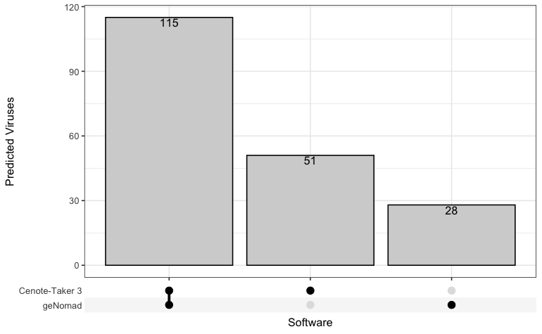

```r
ERR8081307_upset_ct_dt <- assign_overlap_id(
  ERR8081307_view_dt,
  contig_col = "input_name",
  start_col = "chunk_start",
  stop_col = "chunk_stop"
) %>%
  group_by(ovl_id) %>%
  summarize(
    hit = sum(!is.na(organism)),
  ) %>%
  ungroup() %>%
  filter(hit >= 1) %>%
  mutate(software = "Cenote-Taker 3")

ERR8081307_upset_gnmd_dt <- assign_overlap_id(
  ERR8081307_view_dt,
  contig_col = "input_name",
  start_col = "chunk_start",
  stop_col = "chunk_stop"
) %>%
  group_by(ovl_id) %>%
  summarize(
    hit = sum(!is.na(marker_enrichment)),
  ) %>%
  ungroup() %>%
  filter(hit >= 1) %>%
  mutate(software = "geNomad")


ERR8081307_upset_dt <- rbind(
  ERR8081307_upset_ct_dt,
  ERR8081307_upset_gnmd_dt
) %>%
  group_by(ovl_id) %>%
  summarize(softwares = list(software))

ERR8081307_up_p <- ERR8081307_upset_dt %>%
  ggplot(aes(x= softwares)) +
  geom_bar(color = "black", fill = "lightgrey") +
  scale_x_upset() +
  geom_text(stat='count', aes(label=after_stat(count)), vjust=+1.1) +
  labs(
    x = "Software",
    y = "Predicted Viruses"
  ) +
  theme_bw()

ERR8081307_up_p

ggsave(
  ERR8081307_up_p,
  file = sprintf(
    "%s/charts/ERR8081307_disc_upset1.pdf",
    find_rstudio_root_file()
  ),
  width = 3,
  height = 4
)
```

ERR8081307 genomad only stats

```r
ERR8081307_gen_hall_p <- merge(
  ERR8081307_genomad_dt,
  ERR8081307_genomad_only_dt %>% mutate(g_only = "geNomad-only"),
  all.x = T
) %>%
  mutate(g_only = case_when(g_only == "geNomad-only" ~ "geNomad-only", TRUE ~ "CT3 and geNomad")) %>%
  ggplot(aes(x=n_hallmarks)) +
  geom_histogram() +
  facet_wrap(~g_only, ncol = 1) +
  theme_bw() +
  labs(
    x = "geNomad hallmark gene count",
    y = "genome count",
    title = "geNomad hallmark genes/virus MAG"
  )

ERR8081307_gen_hall_p

ggsave(
  ERR8081307_gen_hall_p,
  file = sprintf(
    "%s/charts/ERR8081307_disc_genomad_halls1.pdf",
    find_rstudio_root_file()
  ),
  width = 4,
  height = 4
)
```

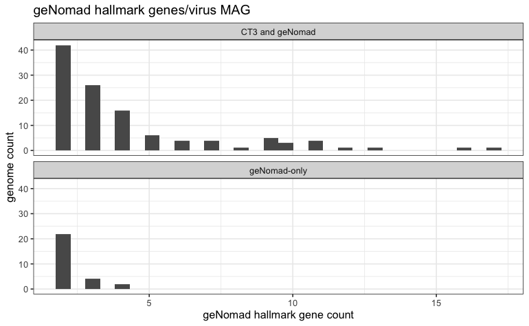

```r
ggsave(
  ERR8081307_gen_hall_p,
  file = sprintf(
    "%s/charts/ERR8081307_disc_genomad_halls1.png",
    find_rstudio_root_file()
  ),
  width = 4,
  height = 4
)
```

ERR8081307 CT3 only stats

```r
ERR8081307_ct3_hall_p <- merge(
  ERR8081307_ct3_only_dt %>% mutate(c_only = "CT3-only"),
  ERR8081307_ct_merge_dt,
  all.y = T
) %>%
  mutate(
    c_only = case_when(c_only == "CT3-only" ~ "CT3-only", TRUE ~ "CT3 and geNomad"),
    n_hallmarks = virion_hallmark_count + rep_hallmark_count
    ) %>%
  ggplot(aes(x=n_hallmarks)) +
  geom_histogram() +
  facet_wrap(~c_only, ncol = 1) +
  theme_bw() +
  labs(
    x = "CT3 hallmark gene count",
    y = "CT3 count",
    title = "CT3 hallmark genes/virus MAG"
  )

ERR8081307_ct3_hall_p

ggsave(
  ERR8081307_ct3_hall_p,
  file = sprintf(
    "%s/charts/ERR8081307_disc_ct3_halls1.pdf",
    find_rstudio_root_file()
  ),
  width = 4,
  height = 4
)
```

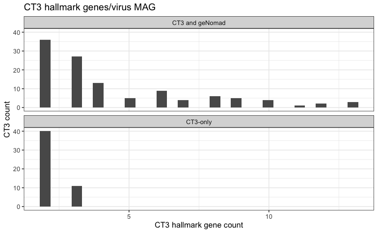

```r
ggsave(
  ERR8081307_ct3_hall_p,
  file = sprintf(
    "%s/charts/ERR8081307_disc_ct3_halls1.png",
    find_rstudio_root_file()
  ),
  width = 4,
  height = 4
)
```

### ERR8081362

load tables

```r
ERR8081362_ct_sum_dt <- fread(
  sprintf(
    "%s/data/discovery/short_read_assemblies/VLP_samples/ct3/ERR8081362_ct3_virus_summary.tsv",
    find_rstudio_root_file()
  ),
  header = T
) %>%
  mutate(input_name = gsub(" .*", "", input_name))

ERR8081362_ct3_prune_dt <- fread(
  sprintf(
    "%s/data/discovery/short_read_assemblies/VLP_samples/ct3/ERR8081362_ct3_prune_summary.tsv",
    find_rstudio_root_file()
  ),
  header = T
) %>%
  mutate(chunk_ID = paste(contig, chunk_name, sep = "@")) %>%
  select(c(chunk_ID, contig_length, chunk_start, chunk_stop))

ERR8081362_ct_merge_dt <- merge(
  ERR8081362_ct_sum_dt,
  ERR8081362_ct3_prune_dt,
  by.x = "contig",
  by.y = "chunk_ID",
  all.x = T
) %>%
  mutate(
    chunk_start = case_when(
      is.na(chunk_start) ~ 0,
      TRUE ~ chunk_start
    ),
    chunk_stop = case_when(
      is.na(chunk_stop) ~ virus_seq_length,
      TRUE ~ chunk_stop
    ),
    input_name = gsub(" \\(.*", "", input_name)
  )
```

```r
ERR8081362_genomad_dt <- fread(
  sprintf(
    "%s/data/discovery/short_read_assemblies/VLP_samples/genomad/ERR8081362.contigs_virus_summary.tsv",
    find_rstudio_root_file()
  ),
  header = T
) %>%
  separate(seq_name,
           sep = "\\|",
           c("input_name", "provirus")) %>%
  separate(coordinates,
           sep = "-",
           c("chunk_start", "chunk_stop")) %>%
  mutate(chunk_start = as.double(chunk_start),
         chunk_stop = as.double(chunk_stop)) %>%
  mutate(
    chunk_start = case_when(
      is.na(chunk_start) ~ 0,
      TRUE ~ chunk_start
    ),
    chunk_stop = case_when(
      is.na(chunk_stop) ~ length,
      TRUE ~ chunk_stop
    )
  ) %>%
  filter(
    n_hallmarks >= 2,
    length >= 1000
    )
```

```r
ERR8081362_full_dt <- merge(
  ERR8081362_ct_merge_dt,
  ERR8081362_genomad_dt,
  by = c("input_name", "chunk_start", "chunk_stop"),
  all = T
)
```

```r
ERR8081362_view_dt <- ERR8081362_full_dt %>%
  select(c(input_name, chunk_start, chunk_stop,
           organism, virion_hallmark_count,
           n_hallmarks, marker_enrichment))
```

```r
ERR8081362_view2_dt <- assign_overlap_id(
  ERR8081362_view_dt,
  contig_col = "input_name",
  start_col = "chunk_start",
  stop_col = "chunk_stop"
) %>%
  group_by(ovl_id) %>%
  summarize(
    approx_len = max(chunk_stop) - min(chunk_start),
    min_start = min(chunk_start),
    max_stop = max(chunk_stop),
    organism = first(organism, na_rm = T),
    virion_hallmark_count = first(virion_hallmark_count, na_rm = T),
    n_hallmarks = first(n_hallmarks, na_rm = T),
    marker_enrichment = first(marker_enrichment, na_rm = T),
  )
```

Cenote-Taker only

```r
ERR8081362_view2_dt %>%
  filter(is.na(n_hallmarks))
```

| ovl_id | approx_len | min_start | max_stop | organism | virion_hallmark_count | n_hallmarks | marker_enrichment |
| --- | --- | --- | --- | --- | --- | --- | --- |
| k99_10523_1 | 1472 | 0 | 1472 | Caudoviricetes sp. ctXQMD2 | 2 | NA | NA |
| k99_10546_1 | 2222 | 0 | 2222 | Caudoviricetes sp. ctVJGCG | 4 | NA | NA |
| k99_11007_1 | 6584 | 0 | 6584 | Caudoviricetes sp. ctBHPZT | 2 | NA | NA |
| k99_11232_1 | 11319 | 0 | 11319 | Caudoviricetes sp. ctGTTBO | 3 | NA | NA |
| k99_11637_1 | 1101 | 0 | 1101 | Caudoviricetes sp. ctIJQ19 | 2 | NA | NA |
| k99_12090_1 | 3169 | 0 | 3169 | Caudoviricetes sp. ct0SNAU | 2 | NA | NA |
| k99_12521_1 | 2123 | 0 | 2123 | Arfiviricetes sp. ctSQD2J | 1 | NA | NA |
| k99_12541_1 | 5160 | 0 | 5160 | Inoviridae sp. ctT2QTU | 1 | NA | NA |
| k99_1943_1 | 1821 | 0 | 1821 | Aliceevansviridae sp. ctZYAV5 | 0 | NA | NA |
| k99_1996_1 | 5777 | 0 | 5777 | Caudoviricetes sp. ctLN54Z | 0 | NA | NA |

[output cut: 24 more lines]

```r
ERR8081362_ct3_only_dt <- ERR8081362_view2_dt %>%
  filter(is.na(n_hallmarks)) %>%
  mutate(
    input_name = gsub("_[0-9]$", "", ovl_id)
  ) %>%
  rename(
    chunk_start = min_start,
    chunk_stop = max_stop
  ) %>%
  select(c(input_name, chunk_start, chunk_stop))

ERR8081362_ct3_contigs <- merge(
  ERR8081362_ct3_only_dt,
  ERR8081362_ct_merge_dt,
  by = c("input_name", "chunk_start", "chunk_stop")
) %>%
  select(c(input_name, contig))

write.table(
  ERR8081362_ct3_contigs$contig,
  file = sprintf(
    "%s/data/discovery/short_read_assemblies/VLP_samples/ERR8081362.ct3_only_contigs.txt",
    find_rstudio_root_file()
  ),
  col.names = F,
  row.names = F,
  quote = F
)
```

Genomad contigs only

```r
ERR8081362_view2_dt %>%
  filter(is.na(virion_hallmark_count))
```

| ovl_id | approx_len | min_start | max_stop | organism | virion_hallmark_count | n_hallmarks | marker_enrichment |
| --- | --- | --- | --- | --- | --- | --- | --- |
| k99_10958_1 | 27761 | 0 | 27761 | NA | NA | 2 | 76.1584 |
| k99_1095_1 | 1554 | 0 | 1554 | NA | NA | 2 | 2.5632 |
| k99_11473_1 | 1773 | 0 | 1773 | NA | NA | 2 | 5.1548 |
| k99_11620_1 | 2686 | 0 | 2686 | NA | NA | 2 | 5.9998 |
| k99_1219_1 | 1186 | 0 | 1186 | NA | NA | 3 | 5.1548 |
| k99_2433_1 | 1897 | 0 | 1897 | NA | NA | 2 | 6.8731 |
| k99_2637_1 | 20365 | 0 | 20365 | NA | NA | 2 | 51.7005 |
| k99_3356_1 | 1304 | 0 | 1304 | NA | NA | 2 | 2.9035 |
| k99_4272_1 | 9745 | 0 | 9745 | NA | NA | 2 | 5.3840 |
| k99_4432_1 | 5400 | 0 | 5400 | NA | NA | 2 | 7.6744 |

[output cut: 2 more lines]

```r
ERR8081362_genomad_only_dt <- ERR8081362_view2_dt %>%
  filter(is.na(virion_hallmark_count)) %>%
  mutate(
    input_name = gsub("_[0-9]$", "", ovl_id)
  ) %>%
  rename(
    chunk_start = min_start,
    chunk_stop = max_stop
  ) %>%
  select(c(input_name, chunk_start, chunk_stop))

ERR8081362_genomad_contigs <- merge(
  ERR8081362_genomad_only_dt,
  ERR8081362_genomad_dt,
  by = c("input_name", "chunk_start", "chunk_stop")
) %>%
  select(c(input_name, provirus)) %>%
  mutate(
    contig = paste(input_name, provirus, sep = "|"),
    contig = gsub("\\|NA", "", contig)
    )

write.table(
  ERR8081362_genomad_contigs$contig,
  file = sprintf(
    "%s/data/discovery/short_read_assemblies/VLP_samples/ERR8081362.gnmd_only_contigs.txt",
    find_rstudio_root_file()
  ),
  col.names = F,
  row.names = F,
  quote = F
)
```

```r
ERR8081362_view2_dt %>%
  filter(!is.na(virion_hallmark_count),
         !is.na(n_hallmarks)
         )
```

| ovl_id | approx_len | min_start | max_stop | organism | virion_hallmark_count | n_hallmarks | marker_enrichment |
| --- | --- | --- | --- | --- | --- | --- | --- |
| k99_10213_1 | 43215 | 0 | 43215 | Caudoviricetes sp. ctND83X | 17 | 14 | 69.6102 |
| k99_10220_1 | 23370 | 0 | 23370 | Caudoviricetes sp. ctYS1TR | 2 | 3 | 31.7797 |
| k99_11064_1 | 29397 | 0 | 29397 | Caudoviricetes sp. ct6BHZ5 | 8 | 5 | 32.7183 |
| k99_11119_1 | 1695 | 0 | 1695 | Caudoviricetes sp. ctKMB1K | 2 | 2 | 2.9592 |
| k99_11260_1 | 2558 | 0 | 2558 | Caudoviricetes sp. ctJIN5W | 3 | 3 | 4.6926 |
| k99_11375_1 | 1782 | 0 | 1782 | Autographivirales sp. ctXT9O2 | 3 | 2 | 3.4366 |
| k99_11388_1 | 33093 | 0 | 33093 | Caudoviricetes sp. ct0SM63 | 14 | 7 | 60.9838 |
| k99_11624_1 | 8520 | 0 | 8520 | Caudoviricetes sp. ctSRRBT | 3 | 2 | 6.5548 |
| k99_11970_1 | 17496 | 0 | 17496 | Caudoviricetes sp. ctMTHW3 | 11 | 8 | 29.4660 |
| k99_12048_1 | 6444 | 0 | 6444 | Caudoviricetes sp. ctL2N8A | 6 | 4 | 6.4864 |

[output cut: 38 more lines]

upset plot

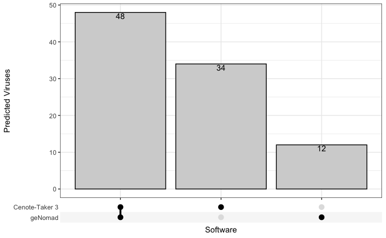

```r
ERR8081362_upset_ct_dt <- assign_overlap_id(
  ERR8081362_view_dt,
  contig_col = "input_name",
  start_col = "chunk_start",
  stop_col = "chunk_stop"
) %>%
  group_by(ovl_id) %>%
  summarize(
    hit = sum(!is.na(organism)),
  ) %>%
  ungroup() %>%
  filter(hit >= 1) %>%
  mutate(software = "Cenote-Taker 3")

ERR8081362_upset_gnmd_dt <- assign_overlap_id(
  ERR8081362_view_dt,
  contig_col = "input_name",
  start_col = "chunk_start",
  stop_col = "chunk_stop"
) %>%
  group_by(ovl_id) %>%
  summarize(
    hit = sum(!is.na(marker_enrichment)),
  ) %>%
  ungroup() %>%
  filter(hit >= 1) %>%
  mutate(software = "geNomad")


ERR8081362_upset_dt <- rbind(
  ERR8081362_upset_ct_dt,
  ERR8081362_upset_gnmd_dt
) %>%
  group_by(ovl_id) %>%
  summarize(softwares = list(software))

ERR8081362_up_p <- ERR8081362_upset_dt %>%
  ggplot(aes(x= softwares)) +
  geom_bar(color = "black", fill = "lightgrey") +
  scale_x_upset() +
  geom_text(stat='count', aes(label=after_stat(count)), vjust=+1.1) +
  labs(
    x = "Software",
    y = "Predicted Viruses"
  ) +
  theme_bw()

ERR8081362_up_p

ggsave(
  ERR8081362_up_p,
  file = sprintf(
    "%s/charts/ERR8081362_disc_upset1.pdf",
    find_rstudio_root_file()
  ),
  width = 3,
  height = 4
)
```

ERR8081362 genomad only stats

```r
ERR8081362_gen_hall_p <- merge(
  ERR8081362_genomad_dt,
  ERR8081362_genomad_only_dt %>% mutate(g_only = "geNomad-only"),
  all.x = T
) %>%
  mutate(g_only = case_when(g_only == "geNomad-only" ~ "geNomad-only", TRUE ~ "CT3 and geNomad")) %>%
  ggplot(aes(x=n_hallmarks)) +
  geom_histogram() +
  facet_wrap(~g_only, ncol = 1) +
  theme_bw() +
  labs(
    x = "geNomad hallmark gene count",
    y = "genome count",
    title = "geNomad hallmark genes/virus MAG"
  )

ERR8081362_gen_hall_p

ggsave(
  ERR8081362_gen_hall_p,
  file = sprintf(
    "%s/charts/ERR8081362_disc_genomad_halls1.pdf",
    find_rstudio_root_file()
  ),
  width = 4,
  height = 4
)
```

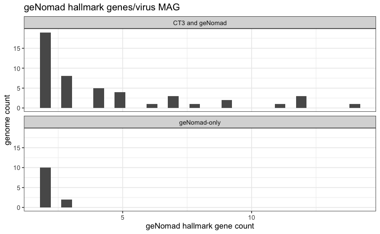

```r
ggsave(
  ERR8081362_gen_hall_p,
  file = sprintf(
    "%s/charts/ERR8081362_disc_genomad_halls1.png",
    find_rstudio_root_file()
  ),
  width = 4,
  height = 4
)
```

ERR8081362 CT3 only stats

```r
ERR8081362_ct3_hall_p <- merge(
  ERR8081362_ct3_only_dt %>% mutate(c_only = "CT3-only"),
  ERR8081362_ct_merge_dt,
  all.y = T
) %>%
  mutate(
    c_only = case_when(c_only == "CT3-only" ~ "CT3-only", TRUE ~ "CT3 and geNomad"),
    n_hallmarks = virion_hallmark_count + rep_hallmark_count
    ) %>%
  ggplot(aes(x=n_hallmarks)) +
  geom_histogram() +
  facet_wrap(~c_only, ncol = 1) +
  theme_bw() +
  labs(
    x = "CT3 hallmark gene count",
    y = "CT3 count",
    title = "CT3 hallmark genes/virus MAG"
  )

ERR8081362_ct3_hall_p

ggsave(
  ERR8081362_ct3_hall_p,
  file = sprintf(
    "%s/charts/ERR8081362_disc_ct3_halls1.pdf",
    find_rstudio_root_file()
  ),
  width = 4,
  height = 4
)
```

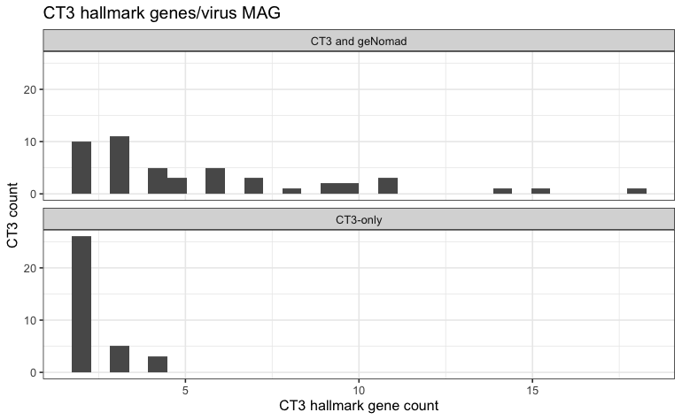

```r
ggsave(
  ERR8081362_ct3_hall_p,
  file = sprintf(
    "%s/charts/ERR8081362_disc_ct3_halls1.png",
    find_rstudio_root_file()
  ),
  width = 4,
  height = 4
)
```

### ERR8081370

load tables

```r
ERR8081370_ct_sum_dt <- fread(
  sprintf(
    "%s/data/discovery/short_read_assemblies/VLP_samples/ct3/ERR8081370_ct3_virus_summary.tsv",
    find_rstudio_root_file()
  ),
  header = T
) %>%
  mutate(input_name = gsub(" .*", "", input_name))

ERR8081370_ct3_prune_dt <- fread(
  sprintf(
    "%s/data/discovery/short_read_assemblies/VLP_samples/ct3/ERR8081370_ct3_prune_summary.tsv",
    find_rstudio_root_file()
  ),
  header = T
) %>%
  mutate(chunk_ID = paste(contig, chunk_name, sep = "@")) %>%
  select(c(chunk_ID, contig_length, chunk_start, chunk_stop))

ERR8081370_ct_merge_dt <- merge(
  ERR8081370_ct_sum_dt,
  ERR8081370_ct3_prune_dt,
  by.x = "contig",
  by.y = "chunk_ID",
  all.x = T
) %>%
  mutate(
    chunk_start = case_when(
      is.na(chunk_start) ~ 0,
      TRUE ~ chunk_start
    ),
    chunk_stop = case_when(
      is.na(chunk_stop) ~ virus_seq_length,
      TRUE ~ chunk_stop
    ),
    input_name = gsub(" \\(.*", "", input_name)
  )
```

```r
ERR8081370_genomad_dt <- fread(
  sprintf(
    "%s/data/discovery/short_read_assemblies/VLP_samples/genomad/ERR8081370.contigs_virus_summary.tsv",
    find_rstudio_root_file()
  ),
  header = T
) %>%
  separate(seq_name,
           sep = "\\|",
           c("input_name", "provirus")) %>%
  separate(coordinates,
           sep = "-",
           c("chunk_start", "chunk_stop")) %>%
  mutate(chunk_start = as.double(chunk_start),
         chunk_stop = as.double(chunk_stop)) %>%
  mutate(
    chunk_start = case_when(
      is.na(chunk_start) ~ 0,
      TRUE ~ chunk_start
    ),
    chunk_stop = case_when(
      is.na(chunk_stop) ~ length,
      TRUE ~ chunk_stop
    )
  ) %>%
  filter(
    n_hallmarks >= 2,
    length >= 1000
    )
```

```r
ERR8081370_full_dt <- merge(
  ERR8081370_ct_merge_dt,
  ERR8081370_genomad_dt,
  by = c("input_name", "chunk_start", "chunk_stop"),
  all = T
)
```

```r
ERR8081370_view_dt <- ERR8081370_full_dt %>%
  select(c(input_name, chunk_start, chunk_stop,
           organism, virion_hallmark_count,
           n_hallmarks, marker_enrichment))
```

```r
ERR8081370_view2_dt <- assign_overlap_id(
  ERR8081370_view_dt,
  contig_col = "input_name",
  start_col = "chunk_start",
  stop_col = "chunk_stop"
) %>%
  group_by(ovl_id) %>%
  summarize(
    approx_len = max(chunk_stop) - min(chunk_start),
    min_start = min(chunk_start),
    max_stop = max(chunk_stop),
    organism = first(organism, na_rm = T),
    virion_hallmark_count = first(virion_hallmark_count, na_rm = T),
    n_hallmarks = first(n_hallmarks, na_rm = T),
    marker_enrichment = first(marker_enrichment, na_rm = T),
  )
```

Cenote-Taker only

```r
ERR8081370_view2_dt %>%
  filter(is.na(n_hallmarks))
```

| ovl_id | approx_len | min_start | max_stop | organism | virion_hallmark_count | n_hallmarks | marker_enrichment |
| --- | --- | --- | --- | --- | --- | --- | --- |
| k99_11357_1 | 1123 | 0 | 1123 | Microviridae sp. ctM8HOB | 1 | NA | NA |
| k99_12678_1 | 1882 | 0 | 1882 | Caudoviricetes sp. ctNQTES | 2 | NA | NA |
| k99_13486_1 | 17695 | 0 | 17695 | Caudoviricetes sp. ctODLFL | 2 | NA | NA |
| k99_14721_1 | 1113 | 0 | 1113 | Caudoviricetes sp. ctJI55E | 2 | NA | NA |
| k99_15863_1 | 1949 | 0 | 1949 | Carjivirus sp. ctVZ3JS | 2 | NA | NA |
| k99_15972_1 | 2357 | 0 | 2357 | Microviridae sp. ctJM76F | 1 | NA | NA |
| k99_17478_1 | 2006 | 0 | 2006 | Caudoviricetes sp. ctOECSG | 2 | NA | NA |
| k99_17687_1 | 4084 | 0 | 4084 | Caudoviricetes sp. ctB9SS0 | 0 | NA | NA |
| k99_21428_1 | 3330 | 0 | 3330 | Carjivirus sp. ct2P1ZA | 2 | NA | NA |
| k99_21536_1 | 2083 | 0 | 2083 | Caudoviricetes sp. ctRNJ24 | 3 | NA | NA |

[output cut: 15 more lines]

```r
ERR8081370_ct3_only_dt <- ERR8081370_view2_dt %>%
  filter(is.na(n_hallmarks)) %>%
  mutate(
    input_name = gsub("_[0-9]$", "", ovl_id)
  ) %>%
  rename(
    chunk_start = min_start,
    chunk_stop = max_stop
  ) %>%
  select(c(input_name, chunk_start, chunk_stop))

ERR8081370_ct3_contigs <- merge(
  ERR8081370_ct3_only_dt,
  ERR8081370_ct_merge_dt,
  by = c("input_name", "chunk_start", "chunk_stop")
) %>%
  select(c(input_name, contig))

write.table(
  ERR8081370_ct3_contigs$contig,
  file = sprintf(
    "%s/data/discovery/short_read_assemblies/VLP_samples/ERR8081370.ct3_only_contigs.txt",
    find_rstudio_root_file()
  ),
  col.names = F,
  row.names = F,
  quote = F
)
```

Genomad contigs only

```r
ERR8081370_view2_dt %>%
  filter(is.na(virion_hallmark_count))
```

| ovl_id | approx_len | min_start | max_stop | organism | virion_hallmark_count | n_hallmarks | marker_enrichment |
| --- | --- | --- | --- | --- | --- | --- | --- |
| k99_14184_1 | 13421 | 0 | 13421 | NA | NA | 2 | 18.2204 |
| k99_16119_1 | 2499 | 0 | 2499 | NA | NA | 2 | 4.7526 |
| k99_16322_1 | 3617 | 0 | 3617 | NA | NA | 4 | 6.4439 |
| k99_16446_1 | 14360 | 0 | 14360 | NA | NA | 2 | 31.3258 |
| k99_17258_1 | 1799 | 0 | 1799 | NA | NA | 2 | 3.2141 |
| k99_19094_1 | 10934 | 0 | 10934 | NA | NA | 2 | 8.6740 |
| k99_20224_1 | 2832 | 0 | 2832 | NA | NA | 2 | 3.4323 |
| k99_3979_1 | 7109 | 0 | 7109 | NA | NA | 2 | 6.1515 |
| k99_4295_1 | 2677 | 0 | 2677 | NA | NA | 2 | 6.1515 |
| k99_4761_1 | 38238 | 0 | 38238 | NA | NA | 2 | 58.2041 |

[output cut: 2 more lines]

```r
ERR8081370_genomad_only_dt <- ERR8081370_view2_dt %>%
  filter(is.na(virion_hallmark_count)) %>%
  mutate(
    input_name = gsub("_[0-9]$", "", ovl_id)
  ) %>%
  rename(
    chunk_start = min_start,
    chunk_stop = max_stop
  ) %>%
  select(c(input_name, chunk_start, chunk_stop))

ERR8081370_genomad_contigs <- merge(
  ERR8081370_genomad_only_dt,
  ERR8081370_genomad_dt,
  by = c("input_name", "chunk_start", "chunk_stop")
) %>%
  select(c(input_name, provirus)) %>%
  mutate(
    contig = paste(input_name, provirus, sep = "|"),
    contig = gsub("\\|NA", "", contig)
    )

write.table(
  ERR8081370_genomad_contigs$contig,
  file = sprintf(
    "%s/data/discovery/short_read_assemblies/VLP_samples/ERR8081370.gnmd_only_contigs.txt",
    find_rstudio_root_file()
  ),
  col.names = F,
  row.names = F,
  quote = F
)
```

```r
ERR8081370_view2_dt %>%
  filter(!is.na(virion_hallmark_count),
         !is.na(n_hallmarks)
         )
```

| ovl_id | approx_len | min_start | max_stop | organism | virion_hallmark_count | n_hallmarks | marker_enrichment |
| --- | --- | --- | --- | --- | --- | --- | --- |
| k99_10737_1 | 1622 | 0 | 1622 | Caudoviricetes sp. ctUZ3XA | 2 | 2 | 3.1100 |
| k99_11045_1 | 22218 | 0 | 22218 | Caudoviricetes sp. ctO0SL6 | 11 | 5 | 41.2094 |
| k99_11046_1 | 8075 | 0 | 8075 | Caudoviricetes sp. ctY6BZG | 3 | 3 | 13.1147 |
| k99_11049_1 | 1736 | 0 | 1736 | Caudoviricetes sp. ctHON75 | 2 | 2 | 3.2346 |
| k99_11889_1 | 10596 | 0 | 10596 | Caudoviricetes sp. ctKAMXF | 4 | 2 | 17.0767 |
| k99_12137_1 | 9569 | 0 | 9569 | Caudoviricetes sp. ctTYQH6 | 8 | 6 | 15.9330 |
| k99_13584_1 | 2264 | 0 | 2264 | Caudoviricetes sp. ctRVPVU | 2 | 2 | 3.2355 |
| k99_13690_1 | 9890 | 0 | 9890 | Caudoviricetes sp. ctGD282 | 6 | 5 | 20.2727 |
| k99_14558_1 | 3196 | 0 | 3196 | Caudoviricetes sp. ct39219 | 3 | 3 | 3.2782 |
| k99_14890_1 | 7150 | 0 | 7150 | Caudoviricetes sp. ct25DLP | 4 | 4 | 8.7272 |

[output cut: 36 more lines]

upset plot

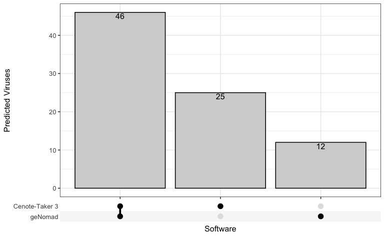

```r
ERR8081370_upset_ct_dt <- assign_overlap_id(
  ERR8081370_view_dt,
  contig_col = "input_name",
  start_col = "chunk_start",
  stop_col = "chunk_stop"
) %>%
  group_by(ovl_id) %>%
  summarize(
    hit = sum(!is.na(organism)),
  ) %>%
  ungroup() %>%
  filter(hit >= 1) %>%
  mutate(software = "Cenote-Taker 3")

ERR8081370_upset_gnmd_dt <- assign_overlap_id(
  ERR8081370_view_dt,
  contig_col = "input_name",
  start_col = "chunk_start",
  stop_col = "chunk_stop"
) %>%
  group_by(ovl_id) %>%
  summarize(
    hit = sum(!is.na(marker_enrichment)),
  ) %>%
  ungroup() %>%
  filter(hit >= 1) %>%
  mutate(software = "geNomad")


ERR8081370_upset_dt <- rbind(
  ERR8081370_upset_ct_dt,
  ERR8081370_upset_gnmd_dt
) %>%
  group_by(ovl_id) %>%
  summarize(softwares = list(software))

ERR8081370_up_p <- ERR8081370_upset_dt %>%
  ggplot(aes(x= softwares)) +
  geom_bar(color = "black", fill = "lightgrey") +
  scale_x_upset() +
  geom_text(stat='count', aes(label=after_stat(count)), vjust=+1.1) +
  labs(
    x = "Software",
    y = "Predicted Viruses"
  ) +
  theme_bw()

ERR8081370_up_p

ggsave(
  ERR8081370_up_p,
  file = sprintf(
    "%s/charts/ERR8081370_disc_upset1.pdf",
    find_rstudio_root_file()
  ),
  width = 3,
  height = 4
)
```

ERR8081370 genomad only stats

```r
ERR8081370_gen_hall_p <- merge(
  ERR8081370_genomad_dt,
  ERR8081370_genomad_only_dt %>% mutate(g_only = "geNomad-only"),
  all.x = T
) %>%
  mutate(g_only = case_when(g_only == "geNomad-only" ~ "geNomad-only", TRUE ~ "CT3 and geNomad")) %>%
  ggplot(aes(x=n_hallmarks)) +
  geom_histogram() +
  facet_wrap(~g_only, ncol = 1) +
  theme_bw() +
  labs(
    x = "geNomad hallmark gene count",
    y = "genome count",
    title = "geNomad hallmark genes/virus MAG"
  )

ERR8081370_gen_hall_p

ggsave(
  ERR8081370_gen_hall_p,
  file = sprintf(
    "%s/charts/ERR8081370_disc_genomad_halls1.pdf",
    find_rstudio_root_file()
  ),
  width = 4,
  height = 4
)
```

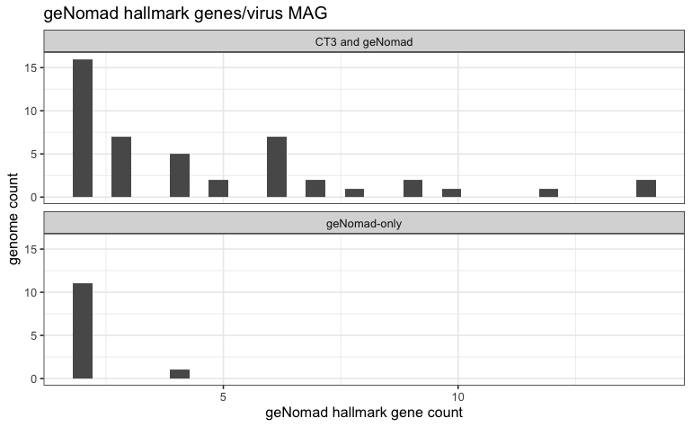

```r
ggsave(
  ERR8081370_gen_hall_p,
  file = sprintf(
    "%s/charts/ERR8081370_disc_genomad_halls1.png",
    find_rstudio_root_file()
  ),
  width = 4,
  height = 4
)
```

ERR8081370 CT3 only stats

```r
ERR8081370_ct3_hall_p <- merge(
  ERR8081370_ct3_only_dt %>% mutate(c_only = "CT3-only"),
  ERR8081370_ct_merge_dt,
  all.y = T
) %>%
  mutate(
    c_only = case_when(c_only == "CT3-only" ~ "CT3-only", TRUE ~ "CT3 and geNomad"),
    n_hallmarks = virion_hallmark_count + rep_hallmark_count
    ) %>%
  ggplot(aes(x=n_hallmarks)) +
  geom_histogram() +
  facet_wrap(~c_only, ncol = 1) +
  theme_bw() +
  labs(
    x = "CT3 hallmark gene count",
    y = "CT3 count",
    title = "CT3 hallmark genes/virus MAG"
  )

ERR8081370_ct3_hall_p

ggsave(
  ERR8081370_ct3_hall_p,
  file = sprintf(
    "%s/charts/ERR8081370_disc_ct3_halls1.pdf",
    find_rstudio_root_file()
  ),
  width = 4,
  height = 4
)
```

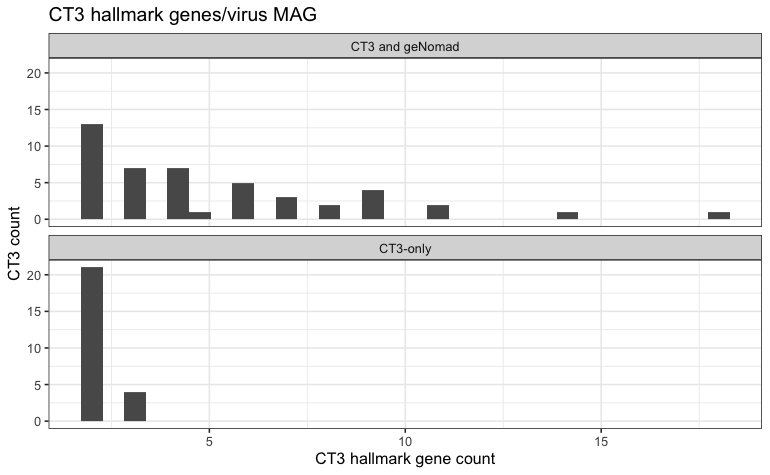

```r
ggsave(
  ERR8081370_ct3_hall_p,
  file = sprintf(
    "%s/charts/ERR8081370_disc_ct3_halls1.png",
    find_rstudio_root_file()
  ),
  width = 4,
  height = 4
)
```

## WGS Accessions

ERR13455686, SRR36807671, SRR36931851

### ERR13455686

load tables

```r
ERR13455686_ct_sum_dt <- fread(
  sprintf(
    "%s/data/discovery/short_read_assemblies/bulk_wgs_samples/ct3/ERR13455686_ct3_virus_summary.tsv",
    find_rstudio_root_file()
  ),
  header = T
) %>%
  mutate(input_name = gsub(" .*", "", input_name))

ERR13455686_ct3_prune_dt <- fread(
  sprintf(
    "%s/data/discovery/short_read_assemblies/bulk_wgs_samples/ct3/ERR13455686_ct3_prune_summary.tsv",
    find_rstudio_root_file()
  ),
  header = T
) %>%
  mutate(chunk_ID = paste(contig, chunk_name, sep = "@")) %>%
  select(c(chunk_ID, contig_length, chunk_start, chunk_stop))

ERR13455686_ct_merge_dt <- merge(
  ERR13455686_ct_sum_dt,
  ERR13455686_ct3_prune_dt,
  by.x = "contig",
  by.y = "chunk_ID",
  all.x = T
) %>%
  mutate(
    chunk_start = case_when(
      is.na(chunk_start) ~ 0,
      TRUE ~ chunk_start
    ),
    chunk_stop = case_when(
      is.na(chunk_stop) ~ virus_seq_length,
      TRUE ~ chunk_stop
    ),
    input_name = gsub(" \\(.*", "", input_name)
  )
```

```r
ERR13455686_genomad_dt <- fread(
  sprintf(
    "%s/data/discovery/short_read_assemblies/bulk_wgs_samples/genomad/ERR13455686.contigs_virus_summary.tsv",
    find_rstudio_root_file()
  ),
  header = T
) %>%
  separate(seq_name,
           sep = "\\|",
           c("input_name", "provirus")) %>%
  separate(coordinates,
           sep = "-",
           c("chunk_start", "chunk_stop")) %>%
  mutate(chunk_start = as.double(chunk_start),
         chunk_stop = as.double(chunk_stop)) %>%
  mutate(
    chunk_start = case_when(
      is.na(chunk_start) ~ 0,
      TRUE ~ chunk_start
    ),
    chunk_stop = case_when(
      is.na(chunk_stop) ~ length,
      TRUE ~ chunk_stop
    )
  ) %>%
  filter(
    n_hallmarks >= 2,
    length >= 1000
    )
```

```r
ERR13455686_full_dt <- merge(
  ERR13455686_ct_merge_dt,
  ERR13455686_genomad_dt,
  by = c("input_name", "chunk_start", "chunk_stop"),
  all = T
)
```

```r
ERR13455686_view_dt <- ERR13455686_full_dt %>%
  select(c(input_name, chunk_start, chunk_stop,
           organism, virion_hallmark_count,
           n_hallmarks, marker_enrichment))
```

```r
ERR13455686_view2_dt <- assign_overlap_id(
  ERR13455686_view_dt,
  contig_col = "input_name",
  start_col = "chunk_start",
  stop_col = "chunk_stop"
) %>%
  group_by(ovl_id) %>%
  summarize(
    approx_len = max(chunk_stop) - min(chunk_start),
    min_start = min(chunk_start),
    max_stop = max(chunk_stop),
    organism = first(organism, na_rm = T),
    virion_hallmark_count = first(virion_hallmark_count, na_rm = T),
    n_hallmarks = first(n_hallmarks, na_rm = T),
    marker_enrichment = first(marker_enrichment, na_rm = T),
  )
```

Cenote-Taker only

```r
ERR13455686_view2_dt %>%
  filter(is.na(n_hallmarks))
```

| ovl_id | approx_len | min_start | max_stop | organism | virion_hallmark_count | n_hallmarks | marker_enrichment |
| --- | --- | --- | --- | --- | --- | --- | --- |
| k99_12063_1 | 8913 | 41595 | 50508 | unclassified virus sp. ctGV8CC | 0 | NA | NA |
| k99_12154_1 | 4712 | 0 | 4712 | Caudoviricetes sp. ctZOO28 | 2 | NA | NA |
| k99_127401_1 | 8737 | 115237 | 123974 | Caudoviricetes sp. ctCPJ14 | 2 | NA | NA |
| k99_131344_1 | 10174 | 0 | 10174 | Caudoviricetes sp. ctV2KB8 | 2 | NA | NA |
| k99_176420_1 | 5009 | 0 | 5009 | Caudoviricetes sp. ct8KJJU | 2 | NA | NA |
| k99_203042_1 | 8053 | 0 | 8053 | Caudoviricetes sp. ctFS8EM | 2 | NA | NA |
| k99_227998_1 | 3076 | 0 | 3076 | Winoviridae sp. ct3R39G | 2 | NA | NA |
| k99_269330_1 | 2129 | 0 | 2129 | Caudoviricetes sp. ctJYP7H | 2 | NA | NA |
| k99_300287_2 | 8026 | 69790 | 77816 | Peduovirus sp. ctF74LC | 4 | NA | NA |
| k99_349256_1 | 1351 | 0 | 1351 | Caudoviricetes sp. ct0TSV6 | 2 | NA | NA |

[output cut: 1 more lines]

```r
ERR13455686_ct3_only_dt <- ERR13455686_view2_dt %>%
  filter(is.na(n_hallmarks)) %>%
  mutate(
    input_name = gsub("_[0-9]$", "", ovl_id)
  ) %>%
  rename(
    chunk_start = min_start,
    chunk_stop = max_stop
  ) %>%
  select(c(input_name, chunk_start, chunk_stop))

ERR13455686_ct3_contigs <- merge(
  ERR13455686_ct3_only_dt,
  ERR13455686_ct_merge_dt,
  by = c("input_name", "chunk_start", "chunk_stop")
) %>%
  select(c(input_name, contig))

write.table(
  ERR13455686_ct3_contigs$contig,
  file = sprintf(
    "%s/data/discovery/short_read_assemblies/bulk_wgs_samples/ERR13455686.ct3_only_contigs.txt",
    find_rstudio_root_file()
  ),
  col.names = F,
  row.names = F,
  quote = F
)
```

Genomad contigs only

```r
ERR13455686_view2_dt %>%
  filter(is.na(virion_hallmark_count))
```

| ovl_id | approx_len | min_start | max_stop | organism | virion_hallmark_count | n_hallmarks | marker_enrichment |
| --- | --- | --- | --- | --- | --- | --- | --- |
| k99_296115_1 | 1779 | 0 | 1779 | NA | NA | 2 | 2.5287 |
| k99_299508_1 | 2388 | 0 | 2388 | NA | NA | 2 | 3.1819 |
| k99_47356_1 | 2259 | 0 | 2259 | NA | NA | 2 | 4.7524 |
| k99_4755_1 | 1407 | 0 | 1407 | NA | NA | 2 | 6.3614 |

```r
ERR13455686_genomad_only_dt <- ERR13455686_view2_dt %>%
  filter(is.na(virion_hallmark_count)) %>%
  mutate(
    input_name = gsub("_[0-9]$", "", ovl_id)
  ) %>%
  rename(
    chunk_start = min_start,
    chunk_stop = max_stop
  ) %>%
  select(c(input_name, chunk_start, chunk_stop))

ERR13455686_genomad_contigs <- merge(
  ERR13455686_genomad_only_dt,
  ERR13455686_genomad_dt,
  by = c("input_name", "chunk_start", "chunk_stop")
) %>%
  select(c(input_name, provirus)) %>%
  mutate(
    contig = paste(input_name, provirus, sep = "|"),
    contig = gsub("\\|NA", "", contig)
    )

write.table(
  ERR13455686_genomad_contigs$contig,
  file = sprintf(
    "%s/data/discovery/short_read_assemblies/bulk_wgs_samples/ERR13455686.gnmd_only_contigs.txt",
    find_rstudio_root_file()
  ),
  col.names = F,
  row.names = F,
  quote = F
)
```

```r
ERR13455686_view2_dt %>%
  filter(!is.na(virion_hallmark_count),
         !is.na(n_hallmarks)
         )
```

| ovl_id | approx_len | min_start | max_stop | organism | virion_hallmark_count | n_hallmarks | marker_enrichment |
| --- | --- | --- | --- | --- | --- | --- | --- |
| k99_129230_1 | 34912 | 8244 | 43156 | Caudoviricetes sp. ctM9GPB | 3 | 5 | 20.9229 |
| k99_132167_1 | 33258 | 86025 | 119283 | Caudoviricetes sp. ctZ19CA | 6 | 6 | 25.2282 |
| k99_153681_1 | 3751 | 0 | 3751 | Caudoviricetes sp. ctZA1DN | 0 | 2 | 3.3393 |
| k99_194480_1 | 2479 | 0 | 2479 | Caudoviricetes sp. ctYRS1H | 3 | 3 | 6.7304 |
| k99_238011_1 | 4495 | 0 | 4495 | Caudoviricetes sp. ctVOTND | 2 | 2 | 10.2799 |
| k99_284839_1 | 27610 | 0 | 27610 | Caudoviricetes sp. ctDNBWA | 17 | 13 | 34.4864 |
| k99_291580_1 | 32551 | 0 | 32551 | Caudoviricetes sp. ctFOE1B | 2 | 2 | 30.8575 |
| k99_291625_1 | 32354 | 0 | 32354 | Caudoviricetes sp. ctO27Z1 | 6 | 10 | 42.0847 |
| k99_300287_1 | 31445 | 33624 | 65069 | Peduovirus sp. ctCZPJ9 | 13 | 12 | 39.4078 |
| k99_300882_1 | 66143 | 27077 | 93220 | Caudoviricetes sp. ctDUUEH | 3 | 3 | 66.4367 |

[output cut: 3 more lines]

upset plot

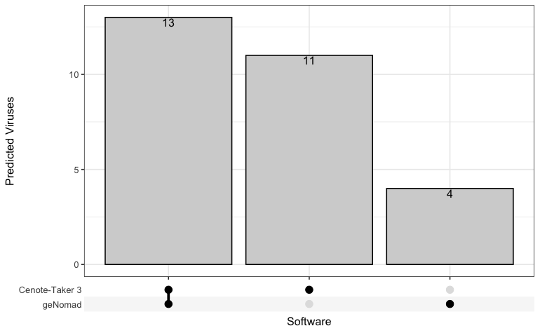

```r
ERR13455686_upset_ct_dt <- assign_overlap_id(
  ERR13455686_view_dt,
  contig_col = "input_name",
  start_col = "chunk_start",
  stop_col = "chunk_stop"
) %>%
  group_by(ovl_id) %>%
  summarize(
    hit = sum(!is.na(organism)),
  ) %>%
  ungroup() %>%
  filter(hit >= 1) %>%
  mutate(software = "Cenote-Taker 3")

ERR13455686_upset_gnmd_dt <- assign_overlap_id(
  ERR13455686_view_dt,
  contig_col = "input_name",
  start_col = "chunk_start",
  stop_col = "chunk_stop"
) %>%
  group_by(ovl_id) %>%
  summarize(
    hit = sum(!is.na(marker_enrichment)),
  ) %>%
  ungroup() %>%
  filter(hit >= 1) %>%
  mutate(software = "geNomad")


ERR13455686_upset_dt <- rbind(
  ERR13455686_upset_ct_dt,
  ERR13455686_upset_gnmd_dt
) %>%
  group_by(ovl_id) %>%
  summarize(softwares = list(software))

ERR13455686_up_p <- ERR13455686_upset_dt %>%
  ggplot(aes(x= softwares)) +
  geom_bar(color = "black", fill = "lightgrey") +
  scale_x_upset() +
  geom_text(stat='count', aes(label=after_stat(count)), vjust=+1.1) +
  labs(
    x = "Software",
    y = "Predicted Viruses"
  ) +
  theme_bw()

ERR13455686_up_p

ggsave(
  ERR13455686_up_p,
  file = sprintf(
    "%s/charts/ERR13455686_disc_upset1.pdf",
    find_rstudio_root_file()
  ),
  width = 3,
  height = 4
)
```

ERR13455686 genomad only stats

```r
ERR13455686_gen_hall_p <- merge(
  ERR13455686_genomad_dt,
  ERR13455686_genomad_only_dt %>% mutate(g_only = "geNomad-only"),
  all.x = T
) %>%
  mutate(g_only = case_when(g_only == "geNomad-only" ~ "geNomad-only", TRUE ~ "CT3 and geNomad")) %>%
  ggplot(aes(x=n_hallmarks)) +
  geom_histogram() +
  facet_wrap(~g_only, ncol = 1) +
  theme_bw() +
  labs(
    x = "geNomad hallmark gene count",
    y = "genome count",
    title = "geNomad hallmark genes/virus MAG"
  )

ERR13455686_gen_hall_p

ggsave(
  ERR13455686_gen_hall_p,
  file = sprintf(
    "%s/charts/ERR13455686_disc_genomad_halls1.pdf",
    find_rstudio_root_file()
  ),
  width = 4,
  height = 4
)
```

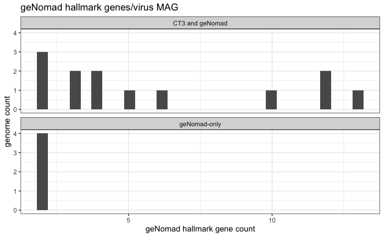

```r
ggsave(
  ERR13455686_gen_hall_p,
  file = sprintf(
    "%s/charts/ERR13455686_disc_genomad_halls1.png",
    find_rstudio_root_file()
  ),
  width = 4,
  height = 4
)
```

ERR13455686 CT3 only stats

```r
ERR13455686_ct3_hall_p <- merge(
  ERR13455686_ct3_only_dt %>% mutate(c_only = "CT3-only"),
  ERR13455686_ct_merge_dt,
  all.y = T
) %>%
  mutate(
    c_only = case_when(c_only == "CT3-only" ~ "CT3-only", TRUE ~ "CT3 and geNomad"),
    n_hallmarks = virion_hallmark_count + rep_hallmark_count
    ) %>%
  ggplot(aes(x=n_hallmarks)) +
  geom_histogram() +
  facet_wrap(~c_only, ncol = 1) +
  theme_bw() +
  labs(
    x = "CT3 hallmark gene count",
    y = "CT3 count",
    title = "CT3 hallmark genes/virus MAG"
  )

ERR13455686_ct3_hall_p

ggsave(
  ERR13455686_ct3_hall_p,
  file = sprintf(
    "%s/charts/ERR13455686_disc_ct3_halls1.pdf",
    find_rstudio_root_file()
  ),
  width = 4,
  height = 4
)
```

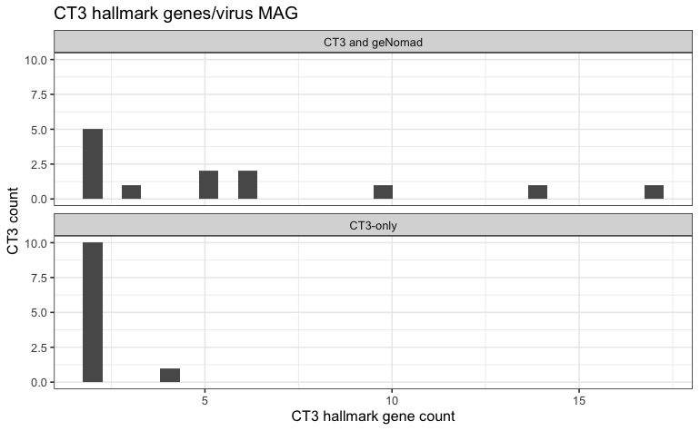

```r
ggsave(
  ERR13455686_ct3_hall_p,
  file = sprintf(
    "%s/charts/ERR13455686_disc_ct3_halls1.png",
    find_rstudio_root_file()
  ),
  width = 4,
  height = 4
)
```

### SRR36807671

load tables

```r
SRR36807671_ct_sum_dt <- fread(
  sprintf(
    "%s/data/discovery/short_read_assemblies/bulk_wgs_samples/ct3/SRR36807671_ct3_virus_summary.tsv",
    find_rstudio_root_file()
  ),
  header = T
) %>%
  mutate(input_name = gsub(" .*", "", input_name))

SRR36807671_ct3_prune_dt <- fread(
  sprintf(
    "%s/data/discovery/short_read_assemblies/bulk_wgs_samples/ct3/SRR36807671_ct3_prune_summary.tsv",
    find_rstudio_root_file()
  ),
  header = T
) %>%
  mutate(chunk_ID = paste(contig, chunk_name, sep = "@")) %>%
  select(c(chunk_ID, contig_length, chunk_start, chunk_stop))

SRR36807671_ct_merge_dt <- merge(
  SRR36807671_ct_sum_dt,
  SRR36807671_ct3_prune_dt,
  by.x = "contig",
  by.y = "chunk_ID",
  all.x = T
) %>%
  mutate(
    chunk_start = case_when(
      is.na(chunk_start) ~ 0,
      TRUE ~ chunk_start
    ),
    chunk_stop = case_when(
      is.na(chunk_stop) ~ virus_seq_length,
      TRUE ~ chunk_stop
    ),
    input_name = gsub(" \\(.*", "", input_name)
  )
```

```r
SRR36807671_genomad_dt <- fread(
  sprintf(
    "%s/data/discovery/short_read_assemblies/bulk_wgs_samples/genomad/SRR36807671.contigs_virus_summary.tsv",
    find_rstudio_root_file()
  ),
  header = T
) %>%
  separate(seq_name,
           sep = "\\|",
           c("input_name", "provirus")) %>%
  separate(coordinates,
           sep = "-",
           c("chunk_start", "chunk_stop")) %>%
  mutate(chunk_start = as.double(chunk_start),
         chunk_stop = as.double(chunk_stop)) %>%
  mutate(
    chunk_start = case_when(
      is.na(chunk_start) ~ 0,
      TRUE ~ chunk_start
    ),
    chunk_stop = case_when(
      is.na(chunk_stop) ~ length,
      TRUE ~ chunk_stop
    )
  ) %>%
  filter(
    n_hallmarks >= 2,
    length >= 1000
    )
```

```r
SRR36807671_full_dt <- merge(
  SRR36807671_ct_merge_dt,
  SRR36807671_genomad_dt,
  by = c("input_name", "chunk_start", "chunk_stop"),
  all = T
)
```

```r
SRR36807671_view_dt <- SRR36807671_full_dt %>%
  select(c(input_name, chunk_start, chunk_stop,
           organism, virion_hallmark_count,
           n_hallmarks, marker_enrichment))
```

```r
SRR36807671_view2_dt <- assign_overlap_id(
  SRR36807671_view_dt,
  contig_col = "input_name",
  start_col = "chunk_start",
  stop_col = "chunk_stop"
) %>%
  group_by(ovl_id) %>%
  summarize(
    approx_len = max(chunk_stop) - min(chunk_start),
    min_start = min(chunk_start),
    max_stop = max(chunk_stop),
    organism = first(organism, na_rm = T),
    virion_hallmark_count = first(virion_hallmark_count, na_rm = T),
    n_hallmarks = first(n_hallmarks, na_rm = T),
    marker_enrichment = first(marker_enrichment, na_rm = T),
  )
```

Cenote-Taker only

```r
SRR36807671_view2_dt %>%
  filter(is.na(n_hallmarks))
```

| ovl_id | approx_len | min_start | max_stop | organism | virion_hallmark_count | n_hallmarks | marker_enrichment |
| --- | --- | --- | --- | --- | --- | --- | --- |
| k99_158281_1 | 2740 | 0 | 2740 | Caudoviricetes sp. ctM0XZ2 | 3 | NA | NA |
| k99_165070_1 | 1349 | 0 | 1349 | Caudoviricetes sp. ctO2AIU | 2 | NA | NA |
| k99_191483_1 | 2694 | 0 | 2694 | Caudoviricetes sp. ctLT0N4 | 2 | NA | NA |
| k99_201610_1 | 4246 | 0 | 4246 | Petitvirales sp. ctDRN88 | 2 | NA | NA |
| k99_347023_1 | 3952 | 0 | 3952 | Caudoviricetes sp. ct5WTGT | 3 | NA | NA |
| k99_348100_1 | 2512 | 0 | 2512 | Caudoviricetes sp. ctC0D9Z | 2 | NA | NA |
| k99_484943_1 | 1914 | 0 | 1914 | Caudoviricetes sp. ctS5B27 | 2 | NA | NA |
| k99_513464_1 | 2039 | 0 | 2039 | Caudoviricetes sp. ct4OKHV | 2 | NA | NA |
| k99_576594_1 | 2285 | 0 | 2285 | Caudoviricetes sp. ctUS60G | 2 | NA | NA |
| k99_579903_1 | 1997 | 0 | 1997 | Caudoviricetes sp. ctB8DPG | 2 | NA | NA |

[output cut: 2 more lines]

```r
SRR36807671_ct3_only_dt <- SRR36807671_view2_dt %>%
  filter(is.na(n_hallmarks)) %>%
  mutate(
    input_name = gsub("_[0-9]$", "", ovl_id)
  ) %>%
  rename(
    chunk_start = min_start,
    chunk_stop = max_stop
  ) %>%
  select(c(input_name, chunk_start, chunk_stop))

SRR36807671_ct3_contigs <- merge(
  SRR36807671_ct3_only_dt,
  SRR36807671_ct_merge_dt,
  by = c("input_name", "chunk_start", "chunk_stop")
) %>%
  select(c(input_name, contig))

write.table(
  SRR36807671_ct3_contigs$contig,
  file = sprintf(
    "%s/data/discovery/short_read_assemblies/bulk_wgs_samples/SRR36807671.ct3_only_contigs.txt",
    find_rstudio_root_file()
  ),
  col.names = F,
  row.names = F,
  quote = F
)
```

Genomad contigs only

```r
SRR36807671_view2_dt %>%
  filter(is.na(virion_hallmark_count))
```

| ovl_id | approx_len | min_start | max_stop | organism | virion_hallmark_count | n_hallmarks | marker_enrichment |
| --- | --- | --- | --- | --- | --- | --- | --- |
| k99_272370_1 | 2583 | 0 | 2583 | NA | NA | 3 | 6.8711 |
| k99_466370_1 | 1303 | 0 | 1303 | NA | NA | 3 | 4.8680 |
| k99_513155_1 | 1007 | 0 | 1007 | NA | NA | 2 | 3.1189 |
| k99_681010_1 | 3899 | 0 | 3899 | NA | NA | 3 | 13.2681 |
| k99_684637_1 | 36905 | 0 | 36905 | NA | NA | 3 | 29.5027 |
| k99_802408_1 | 2260 | 0 | 2260 | NA | NA | 2 | 5.1548 |

```r
SRR36807671_genomad_only_dt <- SRR36807671_view2_dt %>%
  filter(is.na(virion_hallmark_count)) %>%
  mutate(
    input_name = gsub("_[0-9]$", "", ovl_id)
  ) %>%
  rename(
    chunk_start = min_start,
    chunk_stop = max_stop
  ) %>%
  select(c(input_name, chunk_start, chunk_stop))

SRR36807671_genomad_contigs <- merge(
  SRR36807671_genomad_only_dt,
  SRR36807671_genomad_dt,
  by = c("input_name", "chunk_start", "chunk_stop")
) %>%
  select(c(input_name, provirus)) %>%
  mutate(
    contig = paste(input_name, provirus, sep = "|"),
    contig = gsub("\\|NA", "", contig)
    )

write.table(
  SRR36807671_genomad_contigs$contig,
  file = sprintf(
    "%s/data/discovery/short_read_assemblies/bulk_wgs_samples/SRR36807671.gnmd_only_contigs.txt",
    find_rstudio_root_file()
  ),
  col.names = F,
  row.names = F,
  quote = F
)
```

```r
SRR36807671_view2_dt %>%
  filter(!is.na(virion_hallmark_count),
         !is.na(n_hallmarks)
         )
```

| ovl_id | approx_len | min_start | max_stop | organism | virion_hallmark_count | n_hallmarks | marker_enrichment |
| --- | --- | --- | --- | --- | --- | --- | --- |
| k99_163746_1 | 3303 | 0 | 3303 | Caudoviricetes sp. ctW6FNE | 3 | 2 | 4.7025 |
| k99_16463_1 | 17851 | 0 | 17851 | Caudoviricetes sp. ct2R61K | 4 | 4 | 25.6681 |
| k99_27918_1 | 49956 | 11180 | 61136 | Caudoviricetes sp. ct0RQWO | 4 | 7 | 55.5046 |
| k99_282202_1 | 6540 | 0 | 6540 | Caudoviricetes sp. ctHDUZ7 | 3 | 4 | 8.0372 |
| k99_316258_1 | 3508 | 0 | 3508 | Caudoviricetes sp. ctHGNE5 | 3 | 3 | 6.5312 |
| k99_349814_1 | 22571 | 0 | 22571 | Caudoviricetes sp. ctBDRKJ | 6 | 4 | 25.1684 |
| k99_386_1 | 35643 | 0 | 35643 | Caudoviricetes sp. ctHLS6U | 14 | 15 | 42.9363 |
| k99_403555_1 | 6322 | 0 | 6322 | Caudoviricetes sp. ctXIGSI | 2 | 2 | 6.8731 |
| k99_415450_1 | 3715 | 0 | 3715 | Caudoviricetes sp. ctAUGXK | 3 | 3 | 8.5890 |
| k99_452381_1 | 6648 | 0 | 6648 | Caudoviricetes sp. ct7IRKR | 4 | 2 | 5.3976 |

[output cut: 21 more lines]

upset plot

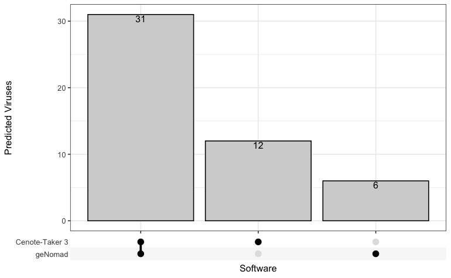

```r
SRR36807671_upset_ct_dt <- assign_overlap_id(
  SRR36807671_view_dt,
  contig_col = "input_name",
  start_col = "chunk_start",
  stop_col = "chunk_stop"
) %>%
  group_by(ovl_id) %>%
  summarize(
    hit = sum(!is.na(organism)),
  ) %>%
  ungroup() %>%
  filter(hit >= 1) %>%
  mutate(software = "Cenote-Taker 3")

SRR36807671_upset_gnmd_dt <- assign_overlap_id(
  SRR36807671_view_dt,
  contig_col = "input_name",
  start_col = "chunk_start",
  stop_col = "chunk_stop"
) %>%
  group_by(ovl_id) %>%
  summarize(
    hit = sum(!is.na(marker_enrichment)),
  ) %>%
  ungroup() %>%
  filter(hit >= 1) %>%
  mutate(software = "geNomad")


SRR36807671_upset_dt <- rbind(
  SRR36807671_upset_ct_dt,
  SRR36807671_upset_gnmd_dt
) %>%
  group_by(ovl_id) %>%
  summarize(softwares = list(software))

SRR36807671_up_p <- SRR36807671_upset_dt %>%
  ggplot(aes(x= softwares)) +
  geom_bar(color = "black", fill = "lightgrey") +
  scale_x_upset() +
  geom_text(stat='count', aes(label=after_stat(count)), vjust=+1.1) +
  labs(
    x = "Software",
    y = "Predicted Viruses"
  ) +
  theme_bw()

SRR36807671_up_p

ggsave(
  SRR36807671_up_p,
  file = sprintf(
    "%s/charts/SRR36807671_disc_upset1.pdf",
    find_rstudio_root_file()
  ),
  width = 3,
  height = 4
)
```

SRR36807671 genomad only stats

```r
SRR36807671_gen_hall_p <- merge(
  SRR36807671_genomad_dt,
  SRR36807671_genomad_only_dt %>% mutate(g_only = "geNomad-only"),
  all.x = T
) %>%
  mutate(g_only = case_when(g_only == "geNomad-only" ~ "geNomad-only", TRUE ~ "CT3 and geNomad")) %>%
  ggplot(aes(x=n_hallmarks)) +
  geom_histogram() +
  facet_wrap(~g_only, ncol = 1) +
  theme_bw() +
  labs(
    x = "geNomad hallmark gene count",
    y = "genome count",
    title = "geNomad hallmark genes/virus MAG"
  )

SRR36807671_gen_hall_p

ggsave(
  SRR36807671_gen_hall_p,
  file = sprintf(
    "%s/charts/SRR36807671_disc_genomad_halls1.pdf",
    find_rstudio_root_file()
  ),
  width = 4,
  height = 4
)
```

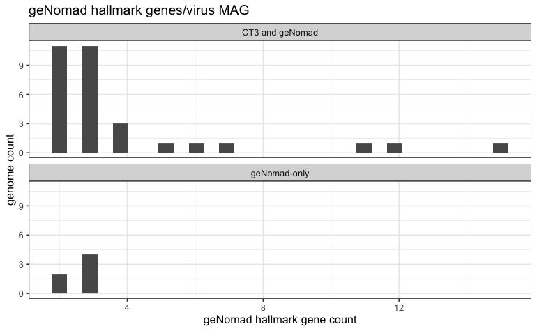

```r
ggsave(
  SRR36807671_gen_hall_p,
  file = sprintf(
    "%s/charts/SRR36807671_disc_genomad_halls1.png",
    find_rstudio_root_file()
  ),
  width = 4,
  height = 4
)
```

SRR36807671 CT3 only stats

```r
SRR36807671_ct3_hall_p <- merge(
  SRR36807671_ct3_only_dt %>% mutate(c_only = "CT3-only"),
  SRR36807671_ct_merge_dt,
  all.y = T
) %>%
  mutate(
    c_only = case_when(c_only == "CT3-only" ~ "CT3-only", TRUE ~ "CT3 and geNomad"),
    n_hallmarks = virion_hallmark_count + rep_hallmark_count
    ) %>%
  ggplot(aes(x=n_hallmarks)) +
  geom_histogram() +
  facet_wrap(~c_only, ncol = 1) +
  theme_bw() +
  labs(
    x = "CT3 hallmark gene count",
    y = "CT3 count",
    title = "CT3 hallmark genes/virus MAG"
  )

SRR36807671_ct3_hall_p

ggsave(
  SRR36807671_ct3_hall_p,
  file = sprintf(
    "%s/charts/SRR36807671_disc_ct3_halls1.pdf",
    find_rstudio_root_file()
  ),
  width = 4,
  height = 4
)
```

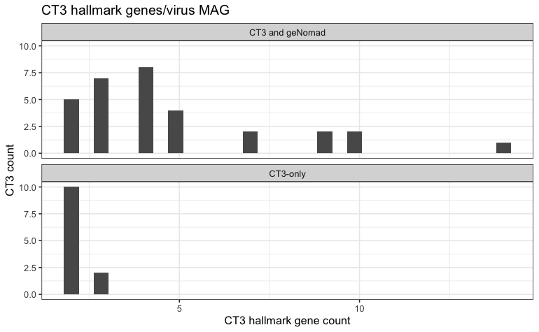

```r
ggsave(
  SRR36807671_ct3_hall_p,
  file = sprintf(
    "%s/charts/SRR36807671_disc_ct3_halls1.png",
    find_rstudio_root_file()
  ),
  width = 4,
  height = 4
)
```

### SRR36931851

load tables

```r
SRR36931851_ct_sum_dt <- fread(
  sprintf(
    "%s/data/discovery/short_read_assemblies/bulk_wgs_samples/ct3/SRR36931851_ct3_virus_summary.tsv",
    find_rstudio_root_file()
  ),
  header = T
) %>%
  mutate(input_name = gsub(" .*", "", input_name))

SRR36931851_ct3_prune_dt <- fread(
  sprintf(
    "%s/data/discovery/short_read_assemblies/bulk_wgs_samples/ct3/SRR36931851_ct3_prune_summary.tsv",
    find_rstudio_root_file()
  ),
  header = T
) %>%
  mutate(chunk_ID = paste(contig, chunk_name, sep = "@")) %>%
  select(c(chunk_ID, contig_length, chunk_start, chunk_stop))

SRR36931851_ct_merge_dt <- merge(
  SRR36931851_ct_sum_dt,
  SRR36931851_ct3_prune_dt,
  by.x = "contig",
  by.y = "chunk_ID",
  all.x = T
) %>%
  mutate(
    chunk_start = case_when(
      is.na(chunk_start) ~ 0,
      TRUE ~ chunk_start
    ),
    chunk_stop = case_when(
      is.na(chunk_stop) ~ virus_seq_length,
      TRUE ~ chunk_stop
    ),
    input_name = gsub(" \\(.*", "", input_name)
  )
```

```r
SRR36931851_genomad_dt <- fread(
  sprintf(
    "%s/data/discovery/short_read_assemblies/bulk_wgs_samples/genomad/SRR36931851.contigs_virus_summary.tsv",
    find_rstudio_root_file()
  ),
  header = T
) %>%
  separate(seq_name,
           sep = "\\|",
           c("input_name", "provirus")) %>%
  separate(coordinates,
           sep = "-",
           c("chunk_start", "chunk_stop")) %>%
  mutate(chunk_start = as.double(chunk_start),
         chunk_stop = as.double(chunk_stop)) %>%
  mutate(
    chunk_start = case_when(
      is.na(chunk_start) ~ 0,
      TRUE ~ chunk_start
    ),
    chunk_stop = case_when(
      is.na(chunk_stop) ~ length,
      TRUE ~ chunk_stop
    )
  ) %>%
  filter(
    n_hallmarks >= 2,
    length >= 1000
    )
```

```r
SRR36931851_full_dt <- merge(
  SRR36931851_ct_merge_dt,
  SRR36931851_genomad_dt,
  by = c("input_name", "chunk_start", "chunk_stop"),
  all = T
)
```

```r
SRR36931851_view_dt <- SRR36931851_full_dt %>%
  select(c(input_name, chunk_start, chunk_stop,
           organism, virion_hallmark_count,
           n_hallmarks, marker_enrichment))
```

```r
SRR36931851_view2_dt <- assign_overlap_id(
  SRR36931851_view_dt,
  contig_col = "input_name",
  start_col = "chunk_start",
  stop_col = "chunk_stop"
) %>%
  group_by(ovl_id) %>%
  summarize(
    approx_len = max(chunk_stop) - min(chunk_start),
    min_start = min(chunk_start),
    max_stop = max(chunk_stop),
    organism = first(organism, na_rm = T),
    virion_hallmark_count = first(virion_hallmark_count, na_rm = T),
    n_hallmarks = first(n_hallmarks, na_rm = T),
    marker_enrichment = first(marker_enrichment, na_rm = T),
  )
```

Cenote-Taker only

```r
SRR36931851_view2_dt %>%
  filter(is.na(n_hallmarks))
```

| ovl_id | approx_len | min_start | max_stop | organism | virion_hallmark_count | n_hallmarks | marker_enrichment |
| --- | --- | --- | --- | --- | --- | --- | --- |
| k99_101125_1 | 8793 | 0 | 8793 | Caudoviricetes sp. ctCNUVJ | 3 | NA | NA |
| k99_102837_1 | 16787 | 30435 | 47222 | Tubulavirales sp. ctO0M82 | 1 | NA | NA |
| k99_104309_1 | 1166 | 0 | 1166 | Caudoviricetes sp. ct3US6B | 2 | NA | NA |
| k99_113708_1 | 11134 | 14461 | 25595 | Caudoviricetes sp. ctLGT5Z | 3 | NA | NA |
| k99_116266_1 | 1445 | 0 | 1445 | Caudoviricetes sp. ctDIWN4 | 2 | NA | NA |
| k99_117885_1 | 3314 | 0 | 3314 | Caudoviricetes sp. ctYBV2U | 0 | NA | NA |
| k99_118784_1 | 7925 | 5494 | 13419 | Caudoviricetes sp. ctL7NB1 | 0 | NA | NA |
| k99_118942_1 | 2344 | 0 | 2344 | Caudoviricetes sp. ctWOT99 | 2 | NA | NA |
| k99_12330_1 | 1261 | 0 | 1261 | Caudoviricetes sp. ctS7P32 | 2 | NA | NA |
| k99_130703_1 | 1552 | 0 | 1552 | Caudoviricetes sp. ctGW8Q8 | 3 | NA | NA |

[output cut: 126 more lines]

```r
SRR36931851_ct3_only_dt <- SRR36931851_view2_dt %>%
  filter(is.na(n_hallmarks)) %>%
  mutate(
    input_name = gsub("_[0-9]$", "", ovl_id)
  ) %>%
  rename(
    chunk_start = min_start,
    chunk_stop = max_stop
  ) %>%
  select(c(input_name, chunk_start, chunk_stop))

SRR36931851_ct3_contigs <- merge(
  SRR36931851_ct3_only_dt,
  SRR36931851_ct_merge_dt,
  by = c("input_name", "chunk_start", "chunk_stop")
) %>%
  select(c(input_name, contig))

write.table(
  SRR36931851_ct3_contigs$contig,
  file = sprintf(
    "%s/data/discovery/short_read_assemblies/bulk_wgs_samples/SRR36931851.ct3_only_contigs.txt",
    find_rstudio_root_file()
  ),
  col.names = F,
  row.names = F,
  quote = F
)
```

Genomad contigs only

```r
SRR36931851_view2_dt %>%
  filter(is.na(virion_hallmark_count))
```

| ovl_id | approx_len | min_start | max_stop | organism | virion_hallmark_count | n_hallmarks | marker_enrichment |
| --- | --- | --- | --- | --- | --- | --- | --- |
| k99_101021_1 | 3989 | 0 | 3989 | NA | NA | 2 | 3.4366 |
| k99_106232_1 | 2086 | 0 | 2086 | NA | NA | 2 | 4.7302 |
| k99_107894_1 | 10180 | 48 | 10228 | NA | NA | 2 | 15.2956 |
| k99_108164_1 | 2270 | 0 | 2270 | NA | NA | 2 | 6.3895 |
| k99_109532_1 | 4994 | 0 | 4994 | NA | NA | 2 | 13.5227 |
| k99_111240_1 | 1918 | 0 | 1918 | NA | NA | 2 | 4.1289 |
| k99_1125_1 | 2749 | 0 | 2749 | NA | NA | 2 | 4.3543 |
| k99_117856_1 | 17494 | 0 | 17494 | NA | NA | 2 | 14.0250 |
| k99_118759_1 | 3769 | 0 | 3769 | NA | NA | 2 | 4.7526 |
| k99_119092_1 | 1797 | 0 | 1797 | NA | NA | 2 | 2.6598 |

[output cut: 125 more lines]

```r
SRR36931851_genomad_only_dt <- SRR36931851_view2_dt %>%
  filter(is.na(virion_hallmark_count)) %>%
  mutate(
    input_name = gsub("_[0-9]$", "", ovl_id)
  ) %>%
  rename(
    chunk_start = min_start,
    chunk_stop = max_stop
  ) %>%
  select(c(input_name, chunk_start, chunk_stop))

SRR36931851_genomad_contigs <- merge(
  SRR36931851_genomad_only_dt,
  SRR36931851_genomad_dt,
  by = c("input_name", "chunk_start", "chunk_stop")
) %>%
  select(c(input_name, provirus)) %>%
  mutate(
    contig = paste(input_name, provirus, sep = "|"),
    contig = gsub("\\|NA", "", contig)
    )

write.table(
  SRR36931851_genomad_contigs$contig,
  file = sprintf(
    "%s/data/discovery/short_read_assemblies/bulk_wgs_samples/SRR36931851.gnmd_only_contigs.txt",
    find_rstudio_root_file()
  ),
  col.names = F,
  row.names = F,
  quote = F
)
```

```r
SRR36931851_view2_dt %>%
  filter(!is.na(virion_hallmark_count),
         !is.na(n_hallmarks)
         )
```

| ovl_id | approx_len | min_start | max_stop | organism | virion_hallmark_count | n_hallmarks | marker_enrichment |
| --- | --- | --- | --- | --- | --- | --- | --- |
| k99_103683_1 | 2989 | 0 | 2989 | Caudoviricetes sp. ct38M3A | 2 | 3 | 6.0475 |
| k99_103923_1 | 2796 | 0 | 2796 | Caudoviricetes sp. ctKAWPN | 2 | 2 | 2.9752 |
| k99_104286_1 | 2854 | 0 | 2854 | Caudoviricetes sp. ctFM5OD | 4 | 2 | 6.6639 |
| k99_108839_1 | 1763 | 0 | 1763 | Caudoviricetes sp. ctKZ2YY | 4 | 3 | 6.8731 |
| k99_109438_1 | 1017 | 0 | 1017 | Caudoviricetes sp. ct0CIGP | 3 | 2 | 4.2419 |
| k99_110407_1 | 21686 | 0 | 21686 | Caudoviricetes sp. ctC9X2T | 12 | 13 | 35.4546 |
| k99_111135_1 | 2284 | 0 | 2284 | Caudoviricetes sp. ctPDKZL | 2 | 2 | 4.7651 |
| k99_113147_1 | 2374 | 0 | 2374 | Caudoviricetes sp. ct9RYLE | 2 | 2 | 2.9720 |
| k99_113326_1 | 10687 | 0 | 10687 | Caudoviricetes sp. ct0Z029 | 2 | 3 | 18.3176 |
| k99_11338_1 | 20922 | 0 | 20922 | Caudoviricetes sp. ctZZW3X | 12 | 12 | 43.2478 |

[output cut: 293 more lines]

upset plot

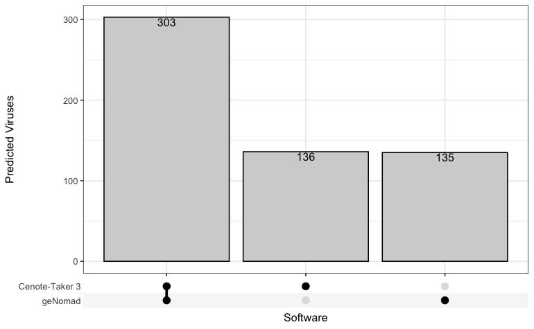

```r
SRR36931851_upset_ct_dt <- assign_overlap_id(
  SRR36931851_view_dt,
  contig_col = "input_name",
  start_col = "chunk_start",
  stop_col = "chunk_stop"
) %>%
  group_by(ovl_id) %>%
  summarize(
    hit = sum(!is.na(organism)),
  ) %>%
  ungroup() %>%
  filter(hit >= 1) %>%
  mutate(software = "Cenote-Taker 3")

SRR36931851_upset_gnmd_dt <- assign_overlap_id(
  SRR36931851_view_dt,
  contig_col = "input_name",
  start_col = "chunk_start",
  stop_col = "chunk_stop"
) %>%
  group_by(ovl_id) %>%
  summarize(
    hit = sum(!is.na(marker_enrichment)),
  ) %>%
  ungroup() %>%
  filter(hit >= 1) %>%
  mutate(software = "geNomad")


SRR36931851_upset_dt <- rbind(
  SRR36931851_upset_ct_dt,
  SRR36931851_upset_gnmd_dt
) %>%
  group_by(ovl_id) %>%
  summarize(softwares = list(software))

SRR36931851_up_p <- SRR36931851_upset_dt %>%
  ggplot(aes(x= softwares)) +
  geom_bar(color = "black", fill = "lightgrey") +
  scale_x_upset() +
  geom_text(stat='count', aes(label=after_stat(count)), vjust=+1.1) +
  labs(
    x = "Software",
    y = "Predicted Viruses"
  ) +
  theme_bw()

SRR36931851_up_p

ggsave(
  SRR36931851_up_p,
  file = sprintf(
    "%s/charts/SRR36931851_disc_upset1.pdf",
    find_rstudio_root_file()
  ),
  width = 3,
  height = 4
)
```

SRR36931851 genomad only stats

```r
SRR36931851_gen_hall_p <- merge(
  SRR36931851_genomad_dt,
  SRR36931851_genomad_only_dt %>% mutate(g_only = "geNomad-only"),
  all.x = T
) %>%
  mutate(g_only = case_when(g_only == "geNomad-only" ~ "geNomad-only", TRUE ~ "CT3 and geNomad")) %>%
  ggplot(aes(x=n_hallmarks)) +
  geom_histogram() +
  facet_wrap(~g_only, ncol = 1) +
  theme_bw() +
  labs(
    x = "geNomad hallmark gene count",
    y = "genome count",
    title = "geNomad hallmark genes/virus MAG"
  )

SRR36931851_gen_hall_p

ggsave(
  SRR36931851_gen_hall_p,
  file = sprintf(
    "%s/charts/SRR36931851_disc_genomad_halls1.pdf",
    find_rstudio_root_file()
  ),
  width = 4,
  height = 4
)
```

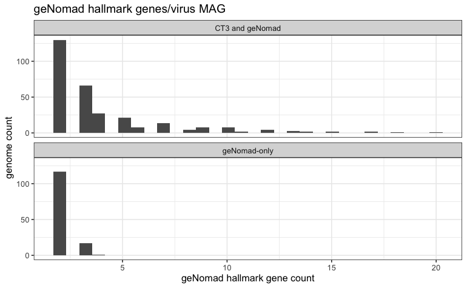

```r
ggsave(
  SRR36931851_gen_hall_p,
  file = sprintf(
    "%s/charts/SRR36931851_disc_genomad_halls1.png",
    find_rstudio_root_file()
  ),
  width = 4,
  height = 4
)
```

SRR36931851 CT3 only stats

```r
SRR36931851_ct3_hall_p <- merge(
  SRR36931851_ct3_only_dt %>% mutate(c_only = "CT3-only"),
  SRR36931851_ct_merge_dt,
  all.y = T
) %>%
  mutate(
    c_only = case_when(c_only == "CT3-only" ~ "CT3-only", TRUE ~ "CT3 and geNomad"),
    n_hallmarks = virion_hallmark_count + rep_hallmark_count
    ) %>%
  ggplot(aes(x=n_hallmarks)) +
  geom_histogram() +
  facet_wrap(~c_only, ncol = 1) +
  theme_bw() +
  labs(
    x = "CT3 hallmark gene count",
    y = "CT3 count",
    title = "CT3 hallmark genes/virus MAG"
  )

SRR36931851_ct3_hall_p

ggsave(
  SRR36931851_ct3_hall_p,
  file = sprintf(
    "%s/charts/SRR36931851_disc_ct3_halls1.pdf",
    find_rstudio_root_file()
  ),
  width = 4,
  height = 4
)
```

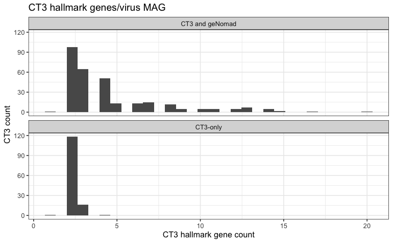

```r
ggsave(
  SRR36931851_ct3_hall_p,
  file = sprintf(
    "%s/charts/SRR36931851_disc_ct3_halls1.png",
    find_rstudio_root_file()
  ),
  width = 4,
  height = 4
)
```